# Introduction to R

### Line Plot

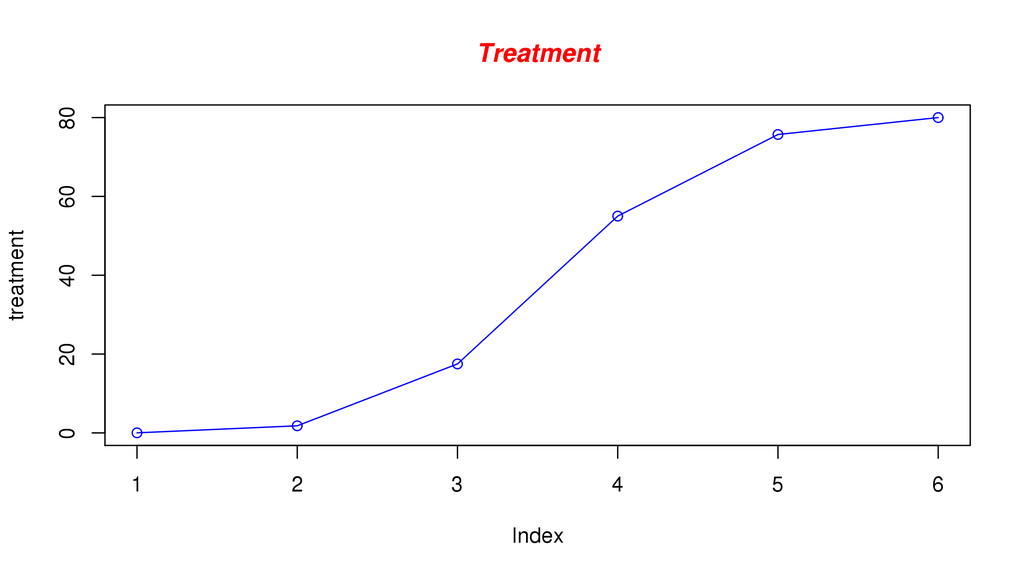

Now let's add a red line for a control vector and specify the y-axis range directly so it will be large enough to fit the data:

Define control vector

```r
control <- c(0, 20, 40, 60, 80,100)
```

Plot treatment using a y axis that ranges from 0 to 100

```r
plot(treatment, type="o", col="blue", ylim=c(0,100))
```

Plot control with red dashed line and square points

```r
lines(control, type="o", pch=22, lty=2, col="red")
```

Create a title with a red, bold/italic font

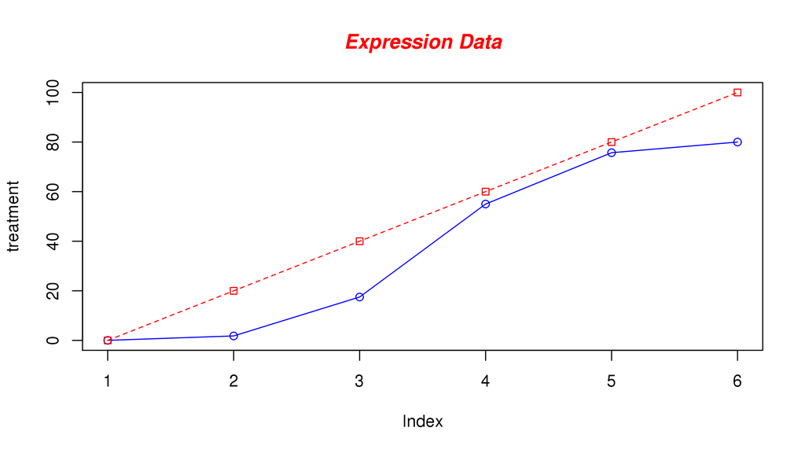

```r
title(main="Expression Data", col.main="red", font.main=4)
```

Next let's change the axes labels to match our data and add a legend. We'll also compute the y-axis values using the max function so any changes to our data will be automatically reflected in our graph.

Calculate range from 0 to max value of data

```r
g_range <- range(0, treatment, control)
```

range returns a vector containing the minimum and maximum of all the given arguments.

Plot treatment using y axis that ranges from 0 to max value in treatment or control vector. Turn off axes and annotations (axis labels) so we can specify them ourselves.

```r
plot(treatment, type="o", col="blue", ylim=g_range,axes=FALSE, ann=FALSE)
```

Make x axis using labels

```r
axis(1, at=1:6, lab=c("Mon","Tue","Wed","Thu","Fri","Sat"))
```

Make y axis with horizontal labels that display ticks at every 20 marks.

```r
axis(2, las=1, at=20*0:g_range[2])
```

Create box around plot

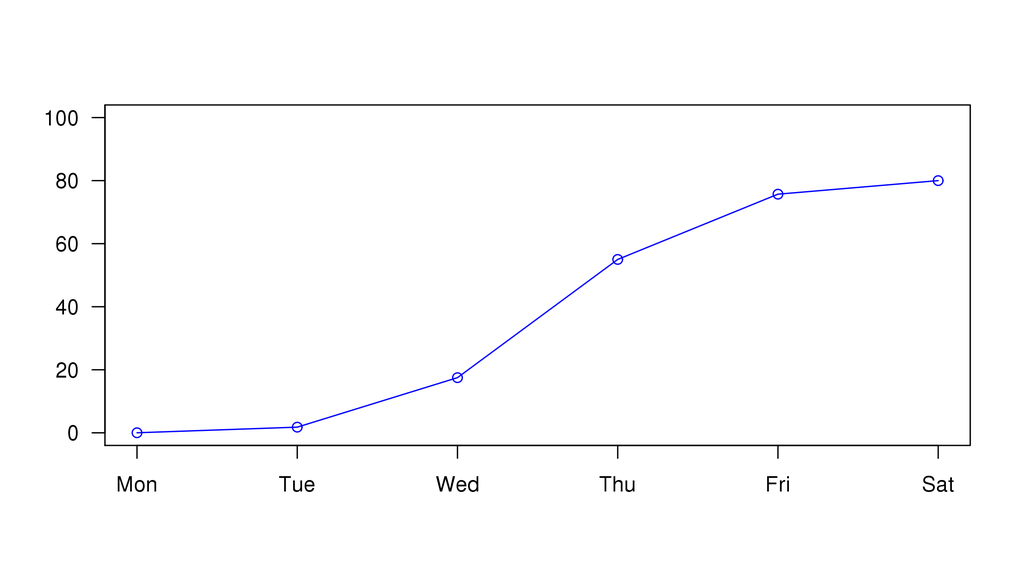

```r
box()
```

Calculate range from 0 to max value of data

```r
g_range <- range(0, treatment, control)
```

range returns a vector containing the minimum and maximum of all the given arguments.

Plot treatment using y axis that ranges from 0 to max value in treatment or control vector. Turn off axes and annotations (axis labels) so we can specify them ourselves.

```r
plot(treatment, type="o", col="blue", ylim=g_range,axes=FALSE, ann=FALSE)
```

Make x axis using labels

```r
axis(1, at=1:6, lab=c("Mon","Tue","Wed","Thu","Fri","Sat"))
```

Make y axis with horizontal labels that display ticks at every 20 marks.

```r
axis(2, las=1, at=20*0:g_range[2])
```

Create box around plot

```r
box()
```

Plot control vector with red dashed line and square points

```r
lines(control, type="o", pch=22, lty=2, col="red")
```

Create a title with a red, bold/italic font

```r
title(main="Data", col.main="red", font.main=4)
```

Label the x and y axes with dark green text

```r
title(xlab="Days", col.lab=rgb(0,0.5,0))
title(ylab="Values", col.lab=rgb(0,0.5,0))
```

Create a legend at (1, g_range[2]) that is slightly smaller (cex) and uses the same line colors and points used by the actual plots

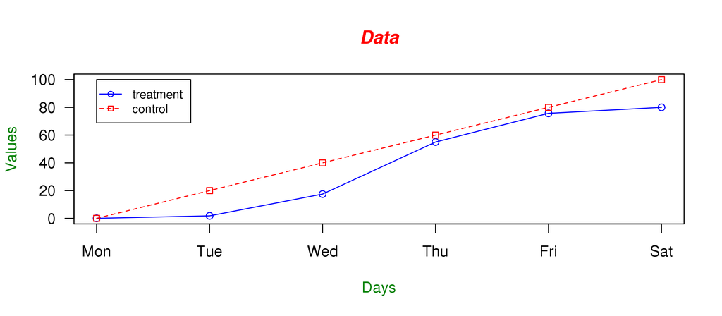

```r
legend(1, g_range[2], c("treatment","control"), cex=0.8, col=c("blue","red"), pch=21:22, lty=1:2);
```

Bar Charts Let's start with a simple bar chart graphing the treatment vector: Plot treatment

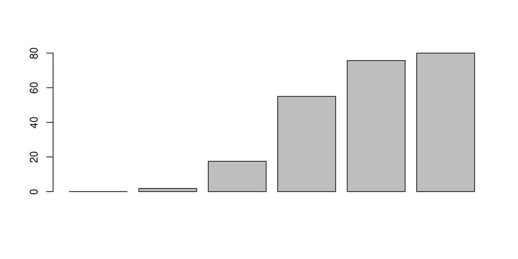

```r
barplot(treatment)
```

Let's now read the data from the example.txt data file, add labels, blue borders around the bars, and density lines:

Read values from tab-delimited example.txt

```r
data <- read.table("example.txt", header=T, sep="\t")
```

Plot treatment with specified labels for axes. Use blue borders and diagonal lines in bars.

```r
barplot(data$treatment, main="Treatment", xlab="Days",ylab="values", names.arg=c("Mon","Tue","Wed","Thu","Fri","Sat"),  border="blue", density=c(10,20,30,40,50,60))
```

names.arg is a vector of names to be plotted below each bar or group of bars. density a vector giving the density of shading lines, in lines per inch, for the bars or bar components.

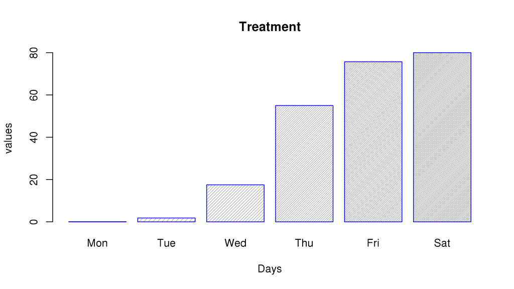

Now let's plot the treatment data using some color and show a legend:

Graph data with adjacent bars using colors

```r
barplot(as.matrix(data), main="Data", ylab= "Total", beside=TRUE, col= c("lightblue", "mistyrose", "lightcyan","lavender", "cornsilk","maroon"))
```

Place the legend at the top-left corner with no frame

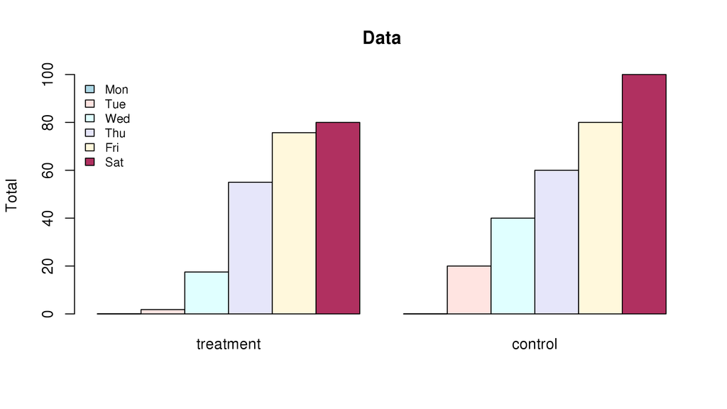

```r
legend("topleft", c("Mon","Tue","Wed","Thu","Fri","Sat"), cex=0.8,bty="n",
fill=  c("lightblue", "mistyrose", "lightcyan","lavender", "cornsilk","maroon"));
```

Histograms Let's start with a simple histogram plotting the distribution of the treatment vector:

Create a histogram for treatment

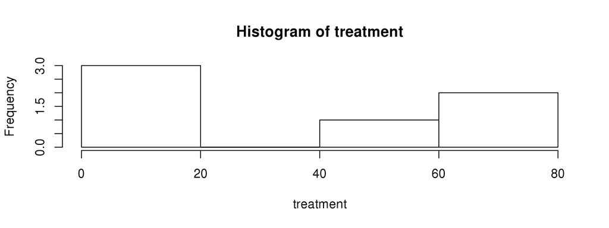

```r
hist(treatment)
```

```r
all <- c(data$control, data$treatment)
```

Create a histogram for data in light blue with the y axis ranging from 0-10

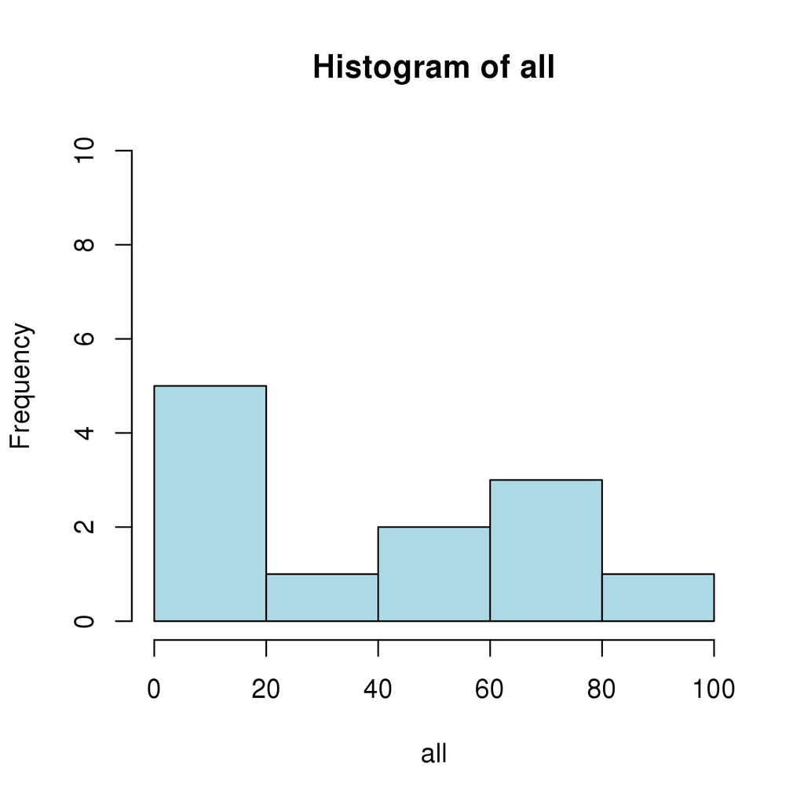

```r
hist(all, col="lightblue", ylim=c(0,10))
```

Now change the breaks so none of the values are grouped together and flip the y-axis labels horizontally.

Compute the largest value used in the data

```r
max_num <- max(all)
```

Create a histogram for data with fire colors, set breaks so each number is in its own group, make x axis range from 0-max_num, disable right-closing of cell intervals, set heading, and make y-axis labels horizontal.

```r
hist(all, col=heat.colors(max_num), breaks=max_num, xlim=c(0,max_num), right=F,
main="Histogram", las=1)
```

breaks: a single number giving the number of cells for the histogram, An open interval does not include its endpoints, and is indicated with parentheses.

For example (0,1) means greater than 0 and less than 1.

A closed interval includes its endpoints, and is denoted with square brackets. For example [0,1] means greater than or equal to 0 and less than or equal to 1.

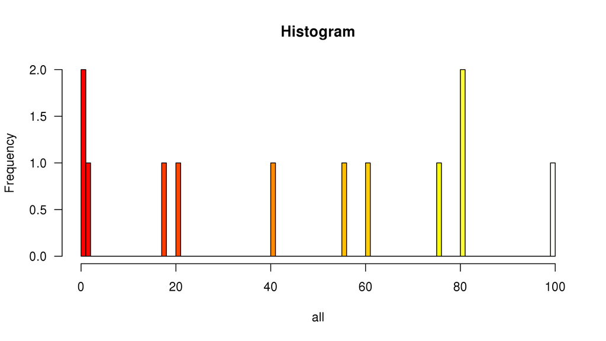

Now let's create uneven breaks and graph the probability density.

Create uneven breaks

```r
brk <- c(0,30,40,50,60,80,100)
```

Create a histogram for all data with fire colours, set uneven breaks, make x axis range from 0-max_num, disable right-closing of cell intervals, set heading, make y-axis labels horizontal, make axis labels smaller, make areas of each column proportional to the count

```r
hist(all, col=heat.colors(length(brk)), breaks=brk,xlim=c(0,max_num), right=F, main="Probability Density",las=1, cex.axis=0.8, freq=F)
```

freq logical; if TRUE, the histogram graphic is a representation of frequencies

if FALSE, probability densities, component density, are plotted

[figure not shown]

Pie Charts Let's start with a simple pie chart graphing the treatment vector: Create a pie chart for treatment

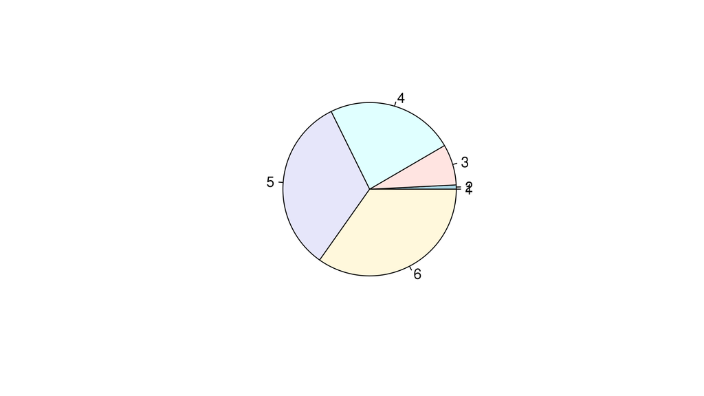

```r
pie(treatment)
```

Now let's add a heading, change the colours, and define our own labels:

Create a pie chart with defined heading and custom colours and labels

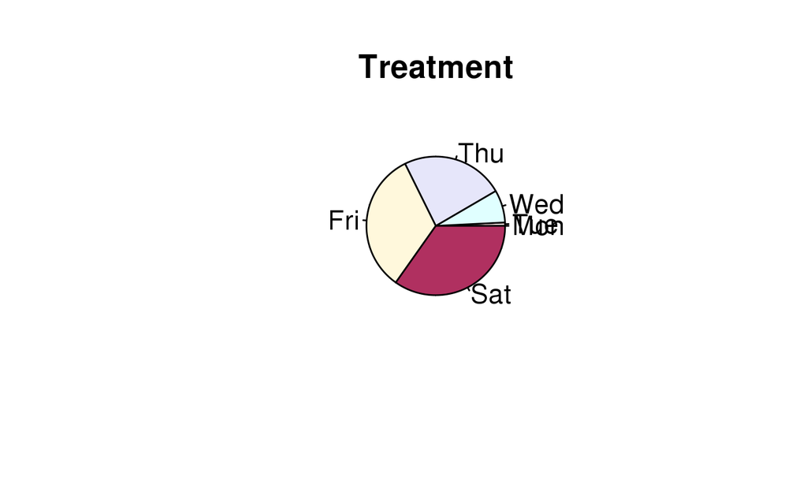

```r
pie(treatment, main="Treatment", col= c("lightblue", "mistyrose", "lightcyan","lavender", "cornsilk","maroon"),
    labels=c("Mon","Tue","Wed","Thu","Fri","Sat"))
```

Now let's change the colours, label using percentages, and create a legend: Define some colours ideal for black & white print

```r
colors <- c("white","grey70","grey90","grey50","black")
```

Calculate the percentage for each day, rounded to one decimal place

```r
treatment_labels <- round(treatment/sum(treatment) * 100, 1)
```

Concatenate a '%' char after each value

```r
treatment_labels <- paste(treatment_labels, "%", sep="")
```

Create a pie chart with defined heading and custom colors and labels

```r
pie(treatment, main="treatment", col=colors, labels= treatment_labels,cex=0.8)
```

Create a legend at the right

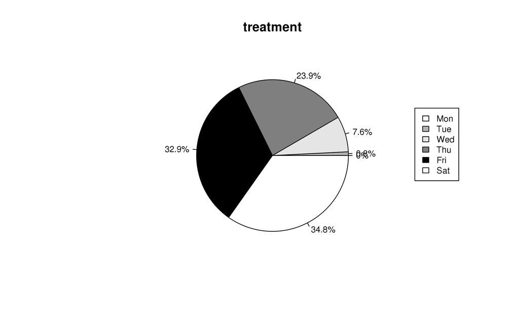

```r
legend(1.5, 0.5, c("Mon","Tue","Wed","Thu","Fri","Sat"), cex=0.8,fill=colors)
```

Dot charts Let's start with a simple dot chart graphing the data:

Create a dot chart for data Function t returns the transpose of a matrix.

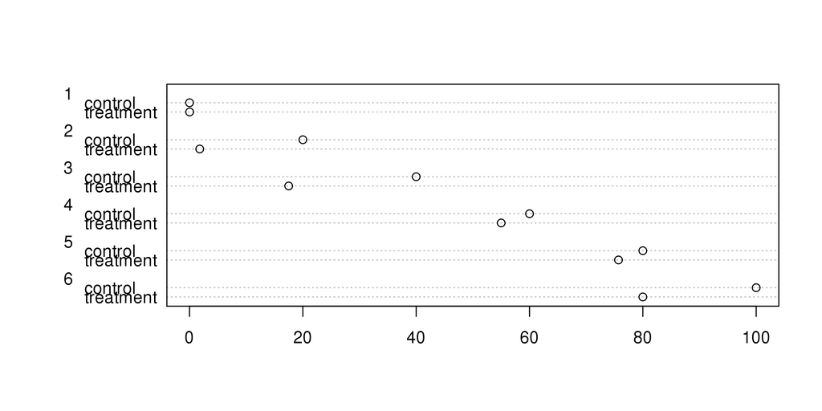

```r
dotchart(t(data))
```

Let's make the dotchart a little more colorful:

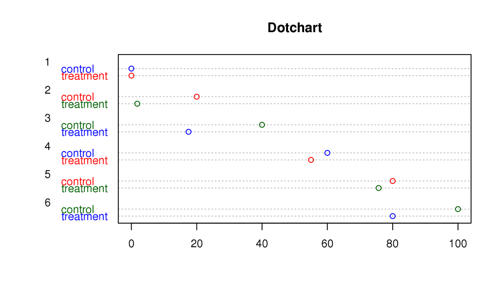

```r
dotchart(t(data), color=c("red","blue","darkgreen"),main="Dotchart", cex=0.8)
```

### Combining Plots

R makes it easy to combine multiple plots into one overall graph, using either the par( ) or layout( ) function. With the par( ) function, you can include the option mfrow=c(nrows, ncols) to create a matrix of nrows x ncols plots that are filled in by row. mfcol=c(nrows, ncols) fills in the matrix by columns.

Define a layout with 2 rows and 2 columns

```r
par(mfrow=c(2,2))
```

Here, we will use different dataset with two columns each for treated and untreated samples.

```r
data1 <- read.table("gene_data.txt", header=T, sep="\t")
head(data1)
```

```
     ensembl_gene_id Untreated1 Untreated2 Treated1 Treated2
1 ENSDARG00000093639     0.8617     1.9311   0.1042   0.1406
2 ENSDARG00000094508     0.9858     2.0256   0.1550   0.2030
3 ENSDARG00000095893     0.8499     1.9876   0.2318   0.2093
4 ENSDARG00000095252     0.9243     2.0858   0.2562   0.2467
5 ENSDARG00000078878     0.3572     0.4654   0.1167   0.0971
6 ENSDARG00000079403     1.0604     1.2581   0.3885   0.3157
```

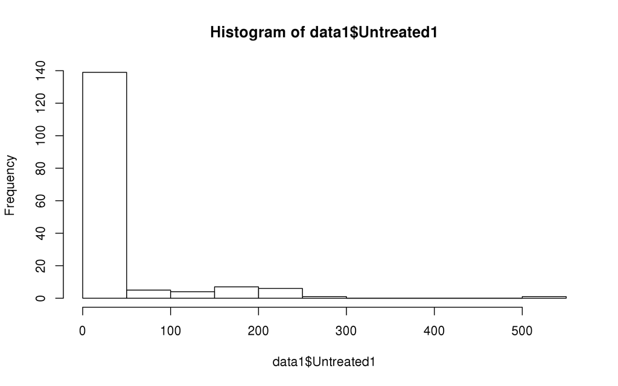

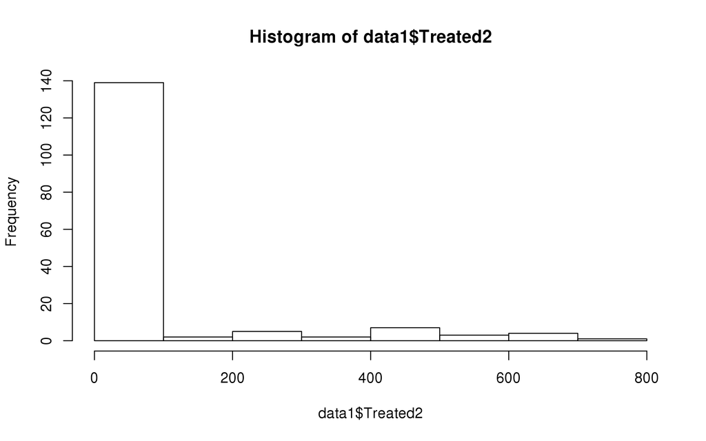

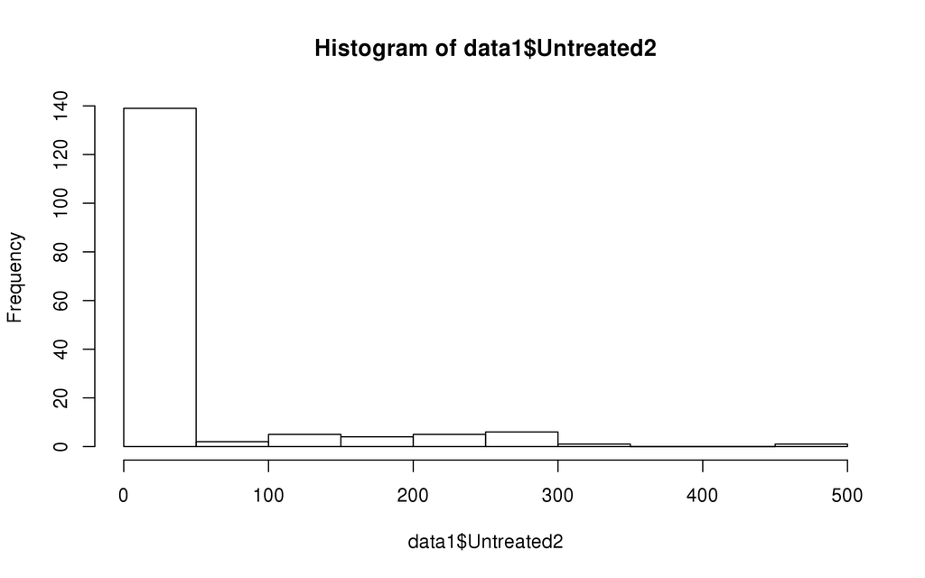

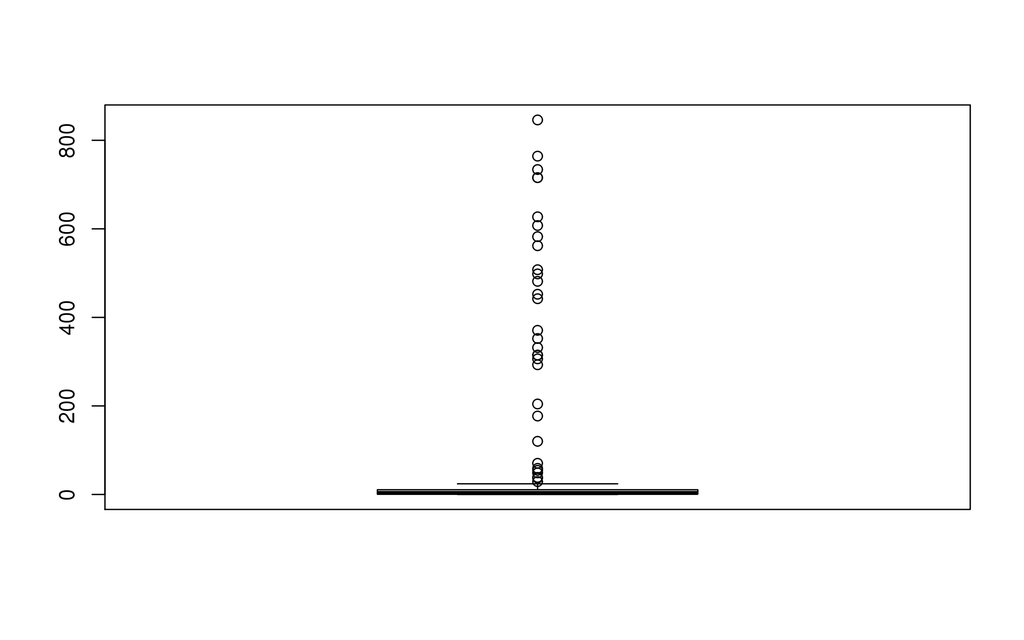

```r
hist(data1$Untreated1)
hist(data1$Treated2)
hist(data1$Untreated2)
boxplot(data1$Treated1)
```

### Saving your plots

There are many different ways of saving your plots in R.

The only argument you would need is name of file in which you want to save the plot.

Plotting commands then can be entered as usual. The output would be redirected to the file.

When you're done with your plotting commands, enter the dev.off() command.

```r
bmp(filename, width = 480, height = 480, units = "px", point-size = 12)
jpeg(filename, width = 480, height = 480, units = "px", point-size = 12, quality = 75)
```

Saving in bitmap format

```r
bmp(file = "control.bmp")
plot(control)
dev.off()
```

Saving in jpeg format

```r
jpeg(file = "control.jpg", quality = 20)
plot(control)
dev.off()
```

Saving in postscript format

```r
postscript(file = "control.ps")
plot(control)
dev.off()
```

```r
saving in pdf format
pdf(file = "control.pdf", paper = "A4")
plot(control)
dev.off()
```

### Lattice R package

Lattice is an excellent package for visualizing multivariate data. It has great set of routines for quickly displaying complex data sets with ease.

Advantages of using lattice package are as following.

Plots with lattice package usually look better.

They can be extended in powerful ways.

The resulting output can be annotated, edited and saved.

Basic form for lattice function call is function.name (formula).

The general arrangement of a formula in a lattice function is: vertical.axis.variable ~ horizontal.axis.variable

Note that the tilde operator (i.e., ~) must be used in a lattice function call, even if the graph only uses a single variable.

For e.g., histogram(~data$x), xyplot(data$y ~ data$x)

Some of the functions available in lattice package are as following: Graphs for univariate data

histogram(), densityplot(),bwplot()

Graphs for showing quantiles of one or more distributions

qqmath(),qq()

Two-dimensional data

xyplot() for creating scatterplots

Let’s start by loading the lattice package.

```r
library(lattice)
```

Read the data from file named gene_data.txt

```r
data <- read.table("gene_data.txt", header=T, sep="\t")
```

A simple scatter plot can be produced as,

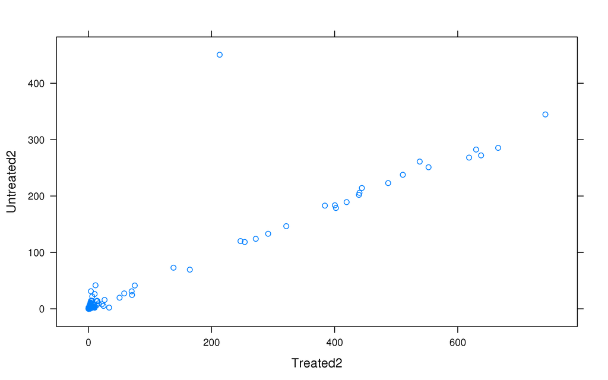

```r
xyplot(Untreated2~Treated2, data=data)
```

or the output can be redirected to an object as,

```r
tplot<-xyplot(Untreated2~Treated2, data=data)
```

and then printed as,

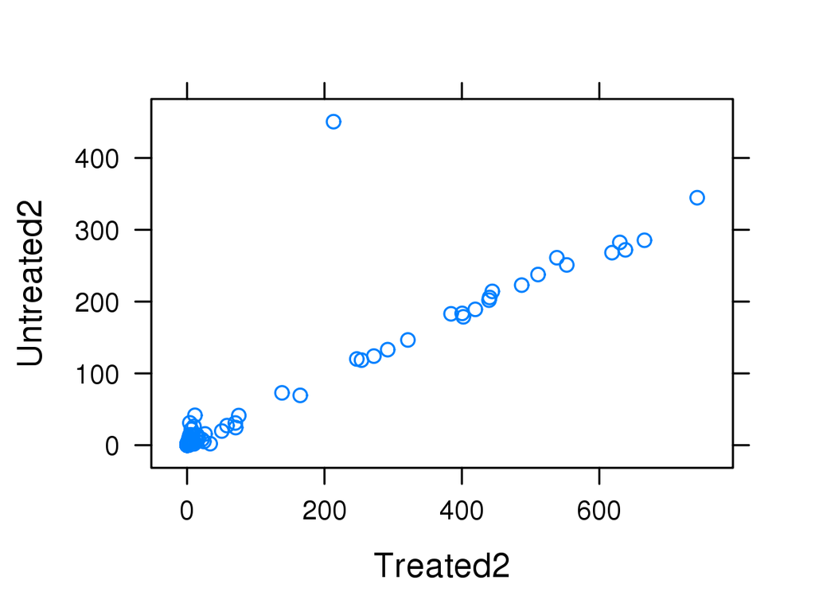

```r
print(tplot)
```

The object containing the plot can further be modified. for e.g.

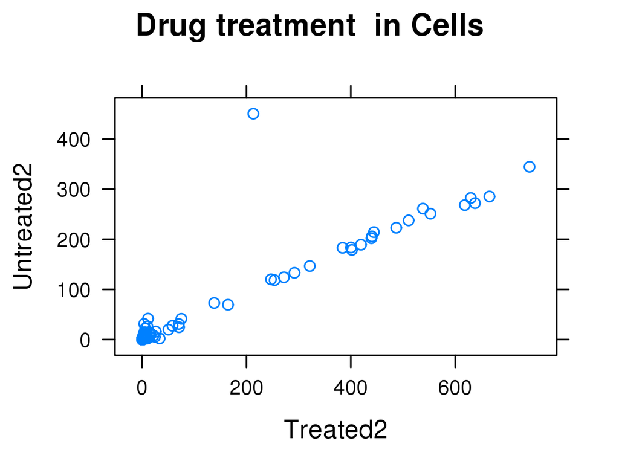

```r
tplot2<-update(tplot, main="Drug treatment  in Cells" )

print(tplot2)
```

Box and whisker plot can be produced with bwplot function. Here, we are again using a singer data frame which is bundled with lattice package. You would have to load lattice package first before using this database.

```r
head(singer)
```

```
  height voice.part
1     64  Soprano 1
2     62  Soprano 1
3     66  Soprano 1
4     65  Soprano 1
5     60  Soprano 1
6     61  Soprano 1
```

```r
bwplot(voice.part ~ height, data=singer, xlab="Height (inches)")
```

[output not shown]

A density plot can be drawn with densityplot function.

```r
densityplot( ~ height | voice.part, data = singer, layout = c(2, 4), xlab = "Height (inches)", bw = 5)
```

[output not shown]

qqmath function is used to draw quantile-Quantile plots of a sample against a theoretical distribution.

```r
qqmath(~ rnorm(100), distribution = function(p) qt(p, df = 10))
```

[output not shown]

### ggplot2 R package

Let's look at how to create a scatterplot in ggplot2. We'll use the iris data frame that's automatically loaded into R. What does the data frame contain? We can use the head function to look at the first few rows

```r
head(iris, n = 3)
```

```
  Sepal.Length Sepal.Width Petal.Length Petal.Width Species
1          5.1         3.5          1.4         0.2  setosa
2          4.9         3.0          1.4         0.2  setosa
3          4.7         3.2          1.3         0.2  setosa
```

by default, head displays the first 6 rows.

```r
head(iris, n = 10)
```

we can also explicitly set the number of rows to display

(The data frame actually contains three types of species: setosa, versicolor, and virginica.)

Let's plot Sepal.Length against Petal.Length using ggplot2's qplot() function.

```r
qplot(Sepal.Length, Petal.Length, data = iris)
```

Plot Sepal.Length vs. Petal.Length, using data from the `iris` data frame. First argument `Sepal.Length` goes on the x-axis. Second argument `Petal.Length` goes on the y-axis. `data = iris` means to look for this data in the `iris` data frame.

To see where each species is located in this graph, we can color each point by adding a color = Species argument.

```r
qplot(Sepal.Length, Petal.Length, data = iris, color = Species)
```

Similarly, we can let the size of each point denote petal width, by adding a size = Petal.Width argument.

```r
qplot(Sepal.Length, Petal.Length, data = iris, color = Species, size = Petal.Width)
```

Finally, let's fix the axis labels and add a title to the plot.

```r
qplot(Sepal.Length, Petal.Length, data = iris, color = Species, xlab = "Sepal Length", ylab = "Petal Length", main = "Sepal vs. Petal Length in Fisher's Iris data")
```

### Other common geoms

In the scatterplot examples above, we implicitly used a point geom, the default when you supply two arguments to qplot(). These two invocations are equivalent.

```r
qplot(Sepal.Length, Petal.Length, data = iris, geom = "point")
qplot(Sepal.Length, Petal.Length, data = iris)
```

But we can also easily use other types of geoms to create more kinds of plots. Barcharts: geom = “bar”

Let’s construct a data frame called movies.

```r
movies = data.frame(
    director = c("spielberg", "spielberg", "spielberg", "jackson", "jackson"),
    movie = c("jaws", "avatar", "schindler's list", "lotr", "king kong"),
    minutes = c(124, 163, 195, 600, 187)
)
```

Plot the number of movies each director has.

```r
qplot(director, data = movies, geom = "bar", ylab = "# movies")
```

By default, the height of each bar is simply a count. But we can also supply a different weight. Here the height of each bar is the total running time of the director's movies.

```r
qplot(director, weight = minutes, data = movies, geom = "bar", ylab = "total length (min.)")
```

### Line charts: geom = "line"

```r
qplot(Sepal.Length, Petal.Length, data = iris, geom = "line", color = Species)
```

`Orange` is another built-in data frame that describes the growth of orange trees.

```r
qplot(age, circumference, data = Orange, geom = "line", colour = Tree,
    main = "How does orange tree circumference vary with age?")
```

We can also plot both points and lines.

```r
qplot(age, circumference, data = Orange, geom = c("point", "line"), colour = Tree)
```

## Simple statistics in R

### Statistics in R

R has a powerful set of in built statistical methods. Including:

- Standard statistical tests
- Statistical modelling
- Further methods available in add on packages

### Tables and Frequencies

One of the simplest statistical tools we have already seen in the function summary() and table(). These functions provide descriptive statistics for data.frames and character vectors or factors.

```r
patientName <- c("patient1","patient2","patient3","patient4")
patientType <- factor(rep(c("male","female"),2))
survivalTime <- c(1,30,2,20)
dfExample <- data.frame(Name=patientName,Type=patientType,Survival_Time=survivalTime)
```

table() provides a breakdown of occurrence of all unique values in vector.

```r
table(patientType)
```

```
patientType
female   male
     2      2
```

summary() provides a breakdown of occurrence of all character or factor columns and min,max,mean and quantiles for numeric columns.

```r
summary(dfExample)
```

```
       Name       Type   Survival_Time
 patient1:1   female:2   Min.   : 1.00
 patient2:1   male  :2   1st Qu.: 1.75
 patient3:1              Median :11.00
 patient4:1              Mean   :13.25
                         3rd Qu.:22.50
                         Max.   :30.00
```

### Tables and Frequencies (continued)

The table() function can be used to generate frequency tables across data.frames.

```r
table(dfExample)
```

```
, , Survival_Time = 1

          Type
Name       female male
  patient1      0    1
  patient2      0    0
  patient3      0    0
  patient4      0    0

, , Survival_Time = 2

          Type
Name       female male
  patient1      0    0
  patient2      0    0
  patient3      0    1
  patient4      0    0

, , Survival_Time = 20

          Type
Name       female male
  patient1      0    0
  patient2      0    0
  patient3      0    0
  patient4      1    0

, , Survival_Time = 30

          Type
Name       female male
  patient1      0    0
  patient2      1    0
  patient3      0    0
  patient4      0    0
```

ftable() function provides a method to generate or print the results from table() in a neater format.

```r
ftable(dfExample)
```

```
                Survival_Time 1 2 20 30
Name     Type
patient1 female               0 0  0  0
         male                 1 0  0  0
patient2 female               0 0  0  1
         male                 0 0  0  0
patient3 female               0 0  0  0
         male                 0 1  0  0
patient4 female               0 0  1  0
         male                 0 0  0  0
```

### Correlation

Another common task in statistical analysis is to investigate the relationship between pairs of numeric vectors.

This can be done by identifying the correlation between numeric vectors using the cor() function in R.

In this example we use cor() to identify the pearson or spearman correlation between two variables.

Perfectly posively correlated vectors will return 1, perfectly negatively correlated vectors will return -1, vectors showing no or little correlation will be close to 0.

```r
x <- rnorm(100,10,2)
z <- rnorm(100,10,2)
y <- x
cor(x,y) #
```

```
[1] 1
```

```r
cor(x,-y)
```

```
[1] -1
```

```r
cor(x,z)
```

```
[1] -0.02373
```

```r
cor(x,z,method="spearman")
```

```
[1] -0.01787
```

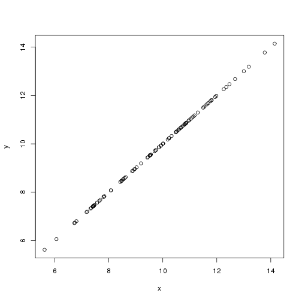

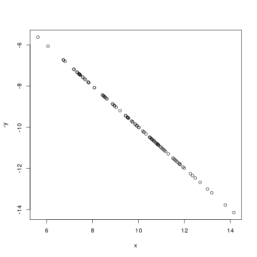

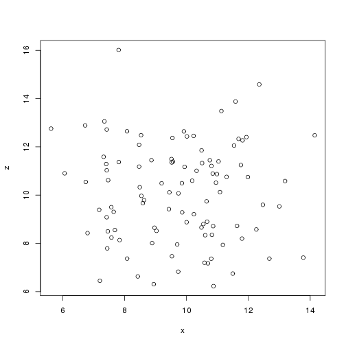

### Correlation (Continued)

Often we wish to apply correlation analysis to all columns or rows in a matrix in a pair-wise ,ammer.

To do this in R, we can simply pass the cor() function a single argument of the numeric matrix of interest. The cor() function will then perform all pair-wise correlations between columns.

```r
minRep[1:2,]
```

```
     Sample_1.hi Sample_2.hi Sample_3.hi Sample_4.low Sample_5.low
[1,]       4.274       4.906       5.634        4.591       0.6031
[2,]       3.708       2.508       2.745        3.368       2.2433
     Sample_1.low
[1,]        5.058
[2,]        2.928
```

```r
cor(minRep)
```

```
             Sample_1.hi Sample_2.hi Sample_3.hi Sample_4.low Sample_5.low
Sample_1.hi      1.00000      0.9133      0.8820      0.01959       0.0424
Sample_2.hi      0.91335      1.0000      0.9621      0.27018       0.2749
Sample_3.hi      0.88204      0.9621      1.0000      0.29194       0.2263
Sample_4.low     0.01959      0.2702      0.2919      1.00000       0.8422
Sample_5.low     0.04240      0.2749      0.2263      0.84215       1.0000
Sample_1.low    -0.06529      0.2733      0.3268      0.91339       0.8112
             Sample_1.low
Sample_1.hi      -0.06529
Sample_2.hi       0.27331
Sample_3.hi       0.32680
Sample_4.low      0.91339
Sample_5.low      0.81122
Sample_1.low      1.00000
```